# Use case: playing video games

## Step 4, `plot_map`: Generate map visualisation

With both the game metadata in the yaml file and the map information in the tsv file, we can finally go ahead and generate our first map visualisation. The map is being generated with a software package called ‘ggplot2’ in R, but first we need to download all the required software for it. Provided that you already have R installed, we need to run the following code to install all of the dependencies. Setup:

```r
install.packages(c("ggforce", "yaml", "bit64", "ggnewscale", "cowplot", "devtools"))
devtools::install("rcannood/civ6saves")
```

Some helper functions are defined in `helper.R` (some code is omitted for the sake of clarity). The `read_header()` and `read_map()` functions respectively read in the yaml and tsv files outputted in the previous steps. The `make_map_plot()` function uses those two data objects and generates a map view of the data provided.

```r
library(tidyverse)
requireNamespace("ggforce", quietly = TRUE)
requireNamespace("civ6saves", quietly = TRUE)
requireNamespace("bit64", quietly = TRUE)
requireNamespace("yaml", quietly = TRUE)
requireNamespace("ggnewscale", quietly = TRUE)

read_header <- function(yaml_file) {
  # read yaml file
  # ... omitted for the sake of clarity ...
}

read_map <- function(tsv_file) {
  # read tsv file
  # ... omitted for the sake of clarity ...
}

make_map_plot <- function(game_data, map_data) {
  # plot map with ggplot2
  # ... omitted for the sake of clarity ...
}
```

With `script.R` we tie all data inputs and helper functies to generate a PDF file of turn 159 of the game we played for you.

```r
library(tidyverse)
library(cowplot)

source("helper.R")

par <- list(
  yaml = "data/AutoSave_0159.yaml",
  tsv = "data/AutoSave_0159.tsv",
  output = "data/AutoSave_0159.pdf"
)

# read data
game_data <- read_header(par$yaml)
map_data <- read_map(par$tsv)

# make visualisation
g <- make_map_plot(game_data, map_data)

# save map to file
gleg <- cowplot::get_legend(g)
gnoleg <- g + theme(legend.position = "none")
gout <- cowplot::plot_grid(gnoleg, gleg, rel_widths = c(8, 1))
ggsave(par$output, gout, width = 24, height = 13)
```

This is what the generated PDF file looks like.

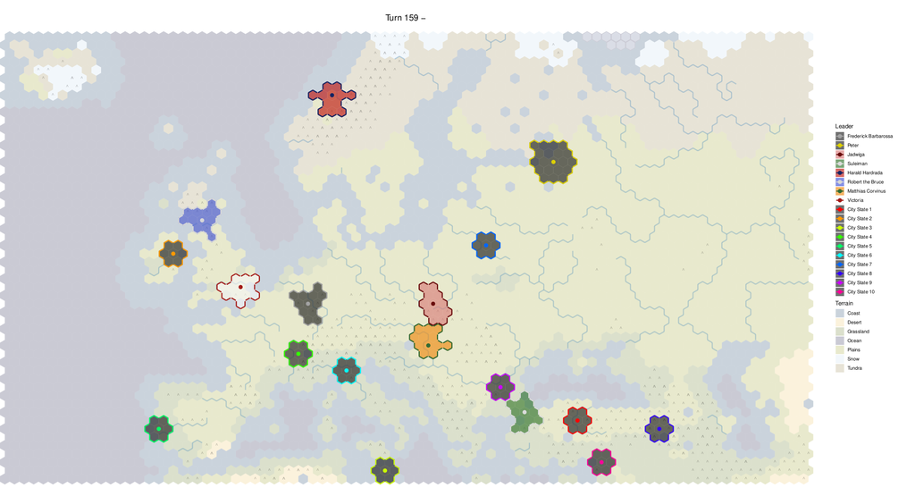

## Step 5, `convert_plot`: Convert PDF to PNG

Setup:

```bash
sudo apt-get install imagemagick
```

Convert:

```bash
#!/bin/bash

par_input=data/AutoSave_0159.pdf
par_output=data/AutoSave_0159.png

convert "$par_input" -flatten "$par_output"
```

## Step 6, `combine_plots`: Create movie

Setup:

```bash
sudo apt-get install ffmpeg
```

Convert:

```bash
#!/bin/bash

par_input="data/AutoSave_0159.png|data/AutoSave_0002.png|..."
par_output="data/Movie.webm"

ffmpeg -framerate 4 -i "concat:$par_input" -c:v libvpx-vp9 -pix_fmt yuva420p -y "$par_output"
```

## Enter viash, stage left

While we at Data Intuitive can now happily churn out postgame videos of all of our Civilization VI, installing the requirements on a different system is a hassle. Because of the complicated software requirements, and because of its pipeline-like workflow, this application is serves as a perfect example of why and how to use [viash](https://www.data-intuitive.com/viash_docs).